# Order Statistics

Zihan Fang

10/17/2020

# 1 Introduction

In this blog post, I will answer a series of questions related to the variation of the median (and a range of other quantiles). I will use analytic methods to answer the questions.

## 1.1 Background

**Which quantiles of a continuous distribution can one estimate with more precision?**

The median is an important quantity in data analysis. It represents the middle value of the data distribution. Estimates of the median, however, have a degree of uncertainty because:

```
(a) the estimates are calculated from a finite sample.
(b) the data distribution of the underlying data is generally unknown.
```

One important roles of a data scientist is to quantify and to communicate the degree of uncertainty in his or her data analysis.

# 2 Questions

**Q1: Begin with the median from a sample of N = 200 from the standard normal distribution. Write an R function that is the density function for the median in this sample. Note that the 100th order statistic is approximately the median, and use the order statistic formula discussed in class. Generate a plot of the function.**

The density function for X<sub>(k)</sub> is

$f_{k}(x)=k{n\choose k}[F(x)]^{k−1}[1−F(x)]^{n−k}f(x)$

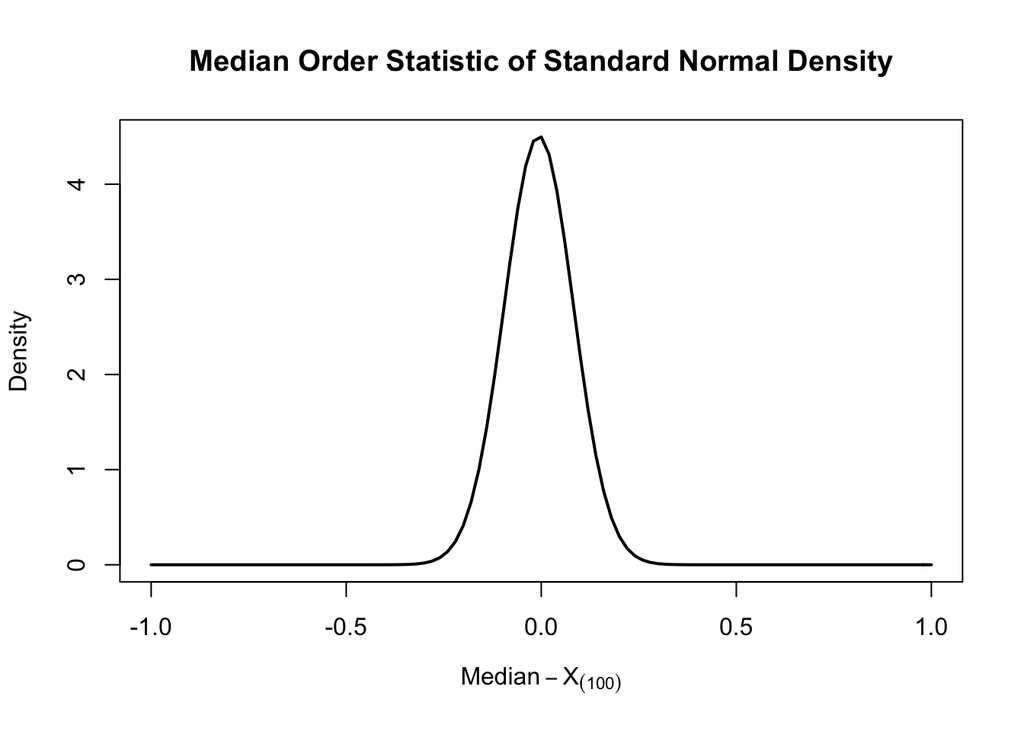

```r
dorder <- function(x,n,k){
  k*choose(n,k)*
  pnorm(x)^(k-1)*
  (1-pnorm(x))^(n-k)*
  dnorm(x)
}

curve(
  dorder(x, n=200, k=100),
  -1,
  1,
  type="l",
  xlab = parse(text = "Median-X[(100)]"),
  ylab = "Density",
  main = "Median Order Statistic of Standard Normal Density",lwd=2
)
```

We could see that the median would mainly fall between (-0.25,0.25) and maximum density of median is 0, which is also the theoretical median for standard normal distribution.

**Q2: Write an R function that is the probability function for the median in this sample. Use the order statistic formula discussed in class. Generate a plot of the function.**

The CDF for X(k) is

$F_{k}(x)=∑_{j=k}^N{n\choose j}[F(x)]^j[1−F(x)]^{n−j}$

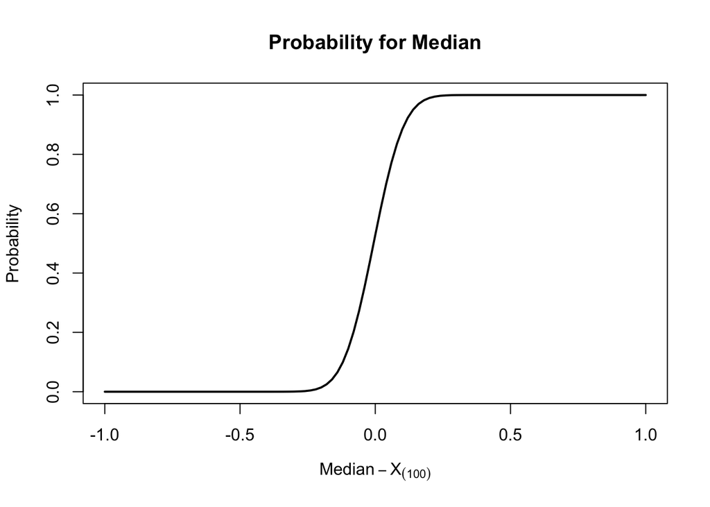

```r
porder <- function(x,n,k){
  pbinom(k-1, n, pnorm(x), lower.tail = FALSE)
}

curve(
  porder(x,n=200,k=100),-1,1,xlab = parse(text = "Median-X[(100)]"),lwd=2,
  ylab = "Probability",
  main = "Probability for Median"
)
```

From this graphic, we can see that most of median would be in (-0.25,0.25).

**Q3: Write an R function that is the quantile function for the median in this sample. (You have several options for how to write this function.) Generate a plot of the function.**

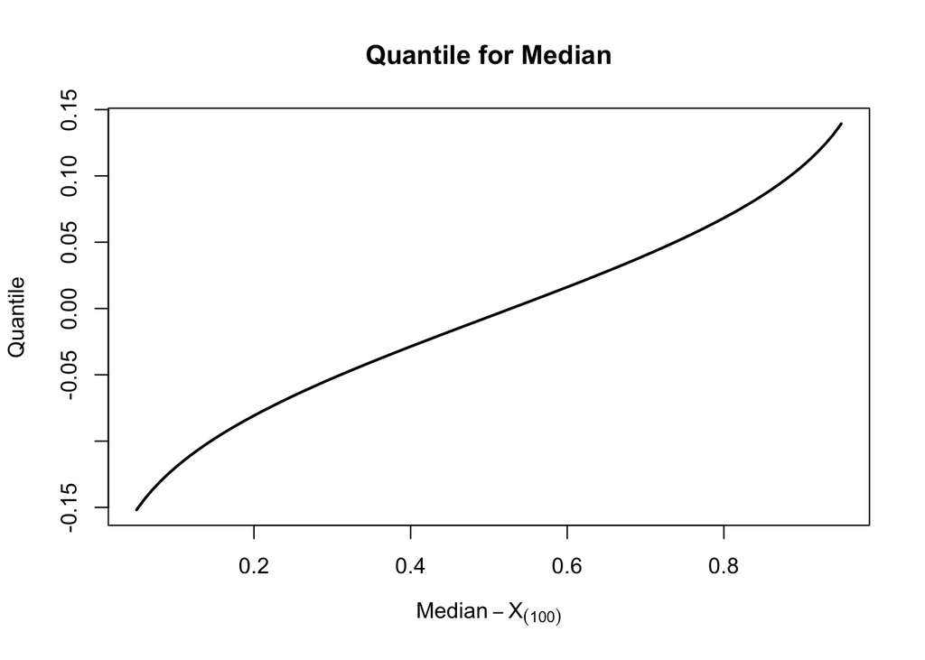

```r
qorder <- function(p,n,k){
  out<-p
  for (i in seq_along(p)){
    out[i] <- uniroot(function(x){porder(x,n,k) - p[i]},c(-100,100))$root
  }
  out
}

p<-seq(0.05,0.95,by=0.01)
plot(p,qorder(p,n=200,k=100),type="l",xlab=parse(text = "Median-X[(100)]"), ylab="Quantile",lwd=2,main = "Quantile for Median")
```

**Q4: Simulate the sampling distribution for the median. Create a plot of the empirical CDF (ECDF). Overlay the plot of the ECDF with a plot of the CDF.**

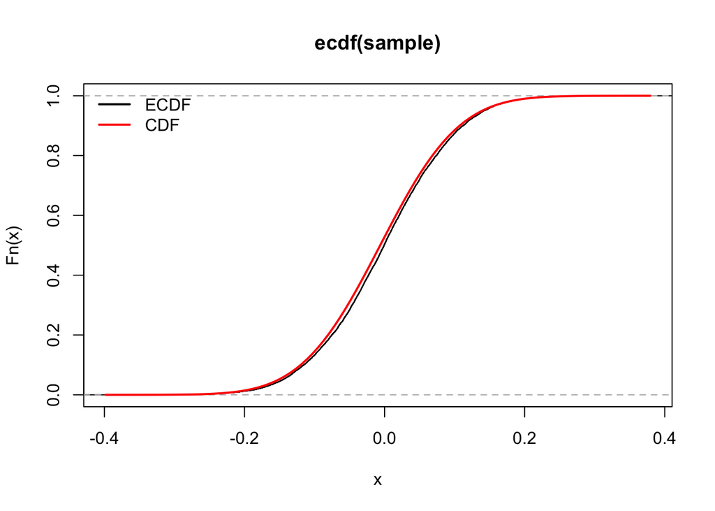

```r
sample=NA

for (i in 1:10000){
  data=rnorm(200)
  sample[i]=median(data)
}

plot(ecdf(sample))
curve(porder(x,n=200,k=100), lwd = 2, add = TRUE, col = "red")
legend("topleft",c("ECDF","CDF"), col = c("black","red"), lwd = 2, bty = "n")
```

The black line is the CDF by simulation(ECDF) for medians and the red line is the analytical CDF for medians. For 10000 simulations, the empirical CDF is almost identical to cdf.

**Q5: Using the simulated sampling distribution from the previous question, create a histogram (on the density scale). Overlay the histogram with a plot of the density function.**

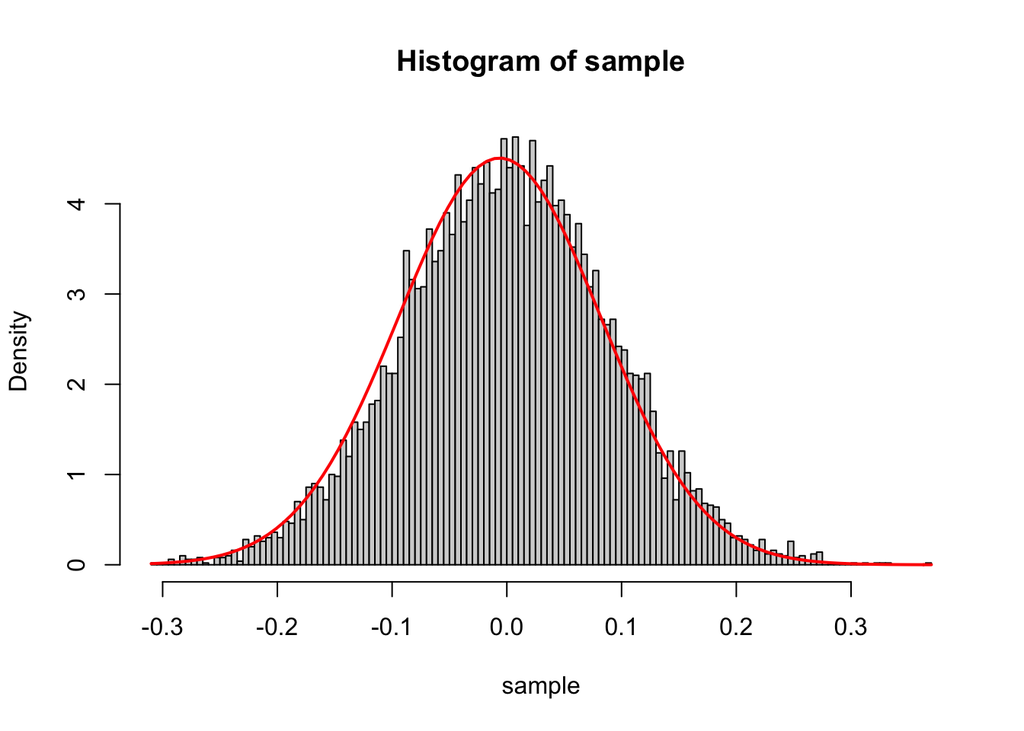

```r
sample=NA

for (i in 1:10000){
  data=rnorm(200)
  sample[i]=median(data)
}

hist(sample, breaks = 100, freq = FALSE)
curve(dorder(x,n=200,k=100), lwd = 2, add = TRUE, col = "red")
```

This is a histogram for simulated medians. The red line is the plot of the density function of medians. We can see that epdf matches the pdf well, so using order statistic approach to get the distribution of medians is accurate.

**Q6: One very common way to compare a random sample to a theoretical candidate distribution is the QQ plot. It is created by ploting quantiles of the theoretical distribution on the x-axis and empirical quantiles from the sample on the y-axis.**

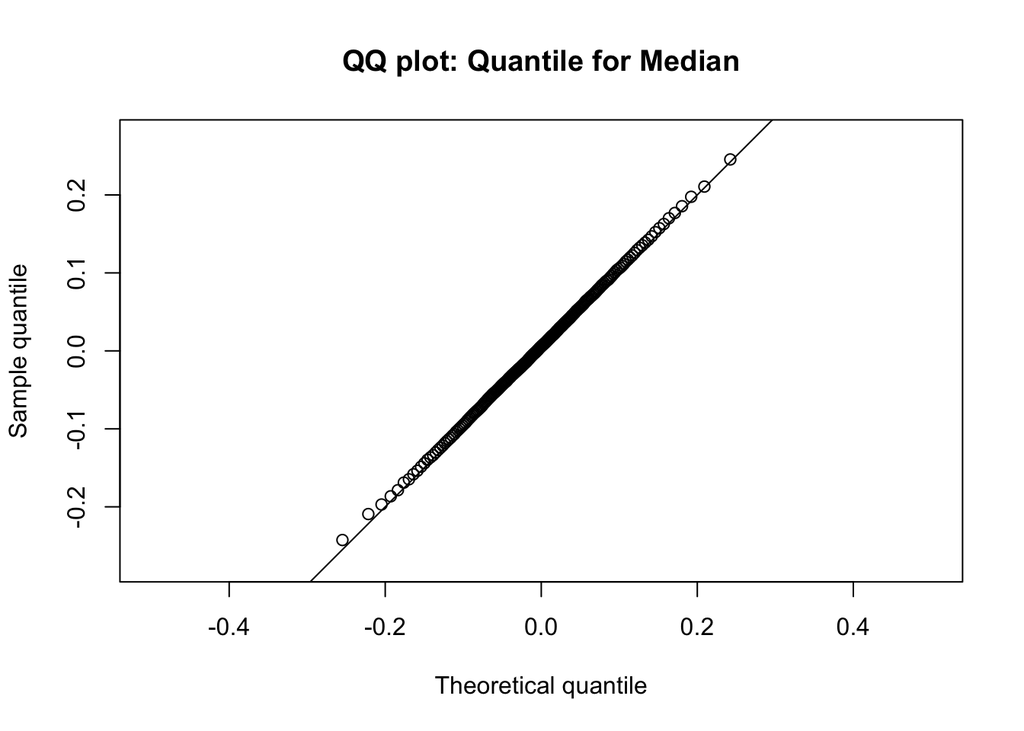

```r
p <- ppoints(200)
sample=NA

for (i in 1:10000){
  data=rnorm(200)
  sample[i]=median(data)
}


plot(x = qorder(p,n=200,k=100),y=quantile(sample, probs = p),
     asp=1,xlim=c(-0.5,0.5),ylim=c(-0.25,0.25),xlab="Theoretical quantile",ylab="Sample quantile",main="QQ plot: Quantile for Median")
abline(0,1)
```

We can see that plotted points nearlt fall along the line y=x, which means that sample and theoretical quantiles come from the same distribution. The simulated data matches the theoretical sampling distribution.

```
random_sample <- rexp(200)
q_candidate <- qexp

x <- q_candidate((1:200)/200)
y <- quantile(random_sample, probs = (1:200)/200)

svg("./assets/exponential-qq.svg", width = 5, height = 3)
tgsify::plotstyle(style = upright)
plot(x,y, asp = 1)
abline(0,1)
dev.off()
```

```
random_sample <- rnorm(200)
q_candidate <- qnorm

x <- q_candidate((1:200)/200)
y <- quantile(random_sample, probs = (1:200)/200)

svg("./assets/normal-qq.svg", width = 5, height = 3)
tgsify::plotstyle(style = upright)
plot(x,y, asp = 1, xlab = "Theoretical quantile", ylab = "Sample quantile")
abline(0,1)
dev.off()
```

```
random_sample <- rt(200, df = 3)
q_candidate <- qnorm

x <- q_candidate((1:200)/200)
y <- quantile(random_sample, probs = (1:200)/200)

svg("./assets/t-normal-qq.svg", width = 5, height = 3)
tgsify::plotstyle(style = upright)
plot(x,y, asp = 1, xlab = "Theoretical quantile", ylab = "Sample quantile")
abline(0,1)
dev.off()
```

**Q7: Modify the `dorder`, `porder`, and `qorder` functions so that the functions take a new parameter `k` (for the k<sup>t ** h</sup> order statistic) so that the functions will work for any order statistic and not just the median.**

```r
# dorder
dorder <- function(x,k){
  k*
  choose(200,k)*
  (pnorm(x))^(k-1)*
  (1-pnorm(x))^(200-k)*
  dnorm(x)
}

# porder
porder <- function(x,k){
  pbinom(k-1, 200, pnorm(x), lower.tail = FALSE)
}

# qorder
qorder <- function(p,k){
  out<-p
  for (i in seq_along(p)){
    out[i] <- uniroot(function(x){porder(x,k)-p[i]},c(-100,100))$root
  }
  out
}
p<-seq(0.05,0.95,by=0.01)
```

**Q8: Generate the QQ plot for simulated data from the sampling distribution of the sample max and the theoretical largest order statistic distribution.**

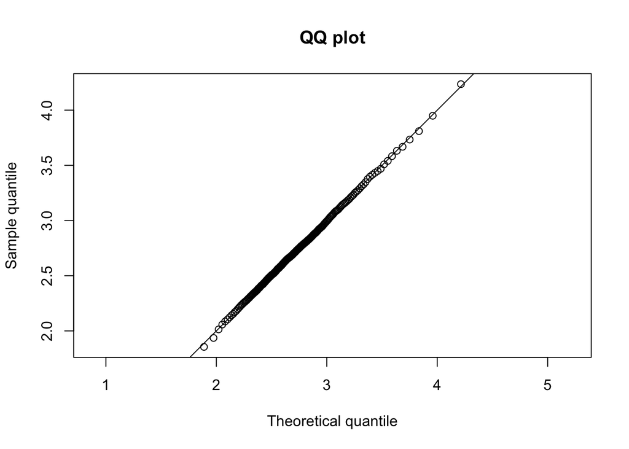

```r
N <- 200
M <- 5000
out <- array(rnorm(M*N), c(M,N))
maxs <- apply(out,1,max)

p <- ppoints(200)
x <- qorder(p, 200)
y <- quantile(maxs, probs = p)

#svg("./assets/max-qq.svg", width = 5, height = 3)
#tgsify::plotstyle(style = upright)
plot(x,y, asp = 1, xlab = "Theoretical quantile", ylab = "Sample quantile",main="QQ plot")
abline(0,1)
```

For this QQ plot, we find plotted points nearly fall along the line y=x. Therefore, we can say the sample max and the theoretical largest order statistic are from the same distribution. The simulated data matches the theoretical sampling distribution.

**Q9: Modify the dorder, porder, and qorder functions so that the functions take new parameters dist and … so that the functions will work for any continuous distribution that has d and p functions defined in R.**

```r
# dorder
dorder <- function(x,k,n,dist="norm",...){
  # use get function to transfer character to function
  pf <- get(paste0("p",dist))
  df <- get(paste0("d",dist))
   k*
    choose(n, k)*
    pf(x, ...)^(k-1)*
    (1-pf(x, ...))^(n-k)*
    df(x, ...)
}

# porder
porder <- function(x,n,k,dist="norm",...){
   # use get function to transfer character to function
  pf <- get(paste0("p",dist))

  pbinom(k-1, n, pf(x,...), lower.tail = FALSE)
}

# qorder
qorder <- function(p,n,k,dist="norm",...){
  out<-p
  for (i in seq_along(p)){
    out[i] <- uniroot(function(x){porder(x,n,k,dist="norm",...)-p[i]},c(-100,100))$root
  }
  out
}
```

**Q10: Use the newly modified functions to plot the probability and density functions for the sample min (N=200).**

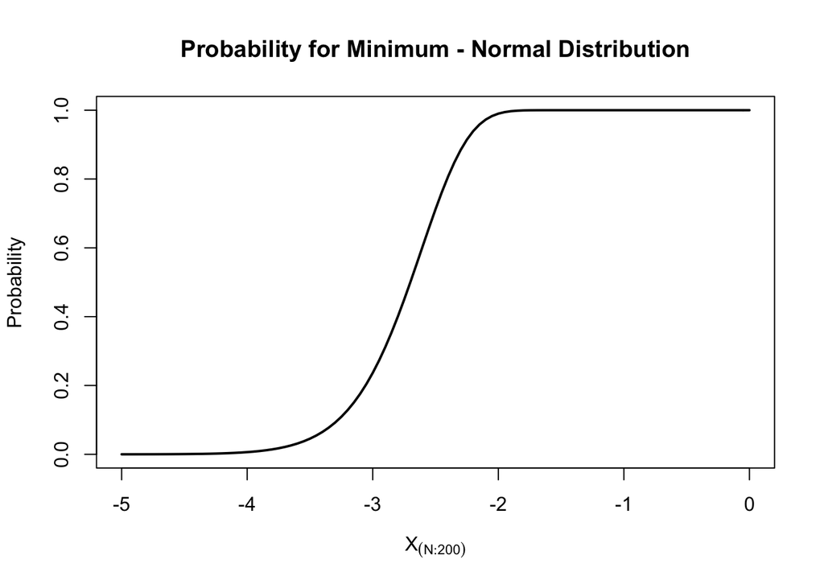

```r
curve(
  porder(x, k=1, n=200, dist = "norm")
  , xlim = c(-5, 0)
  , xlab = parse(text = "X[(N:200)]")
  , ylab = "Probability"
  , lwd = 2
  , main = "Probability for Minimum - Normal Distribution"
)
```

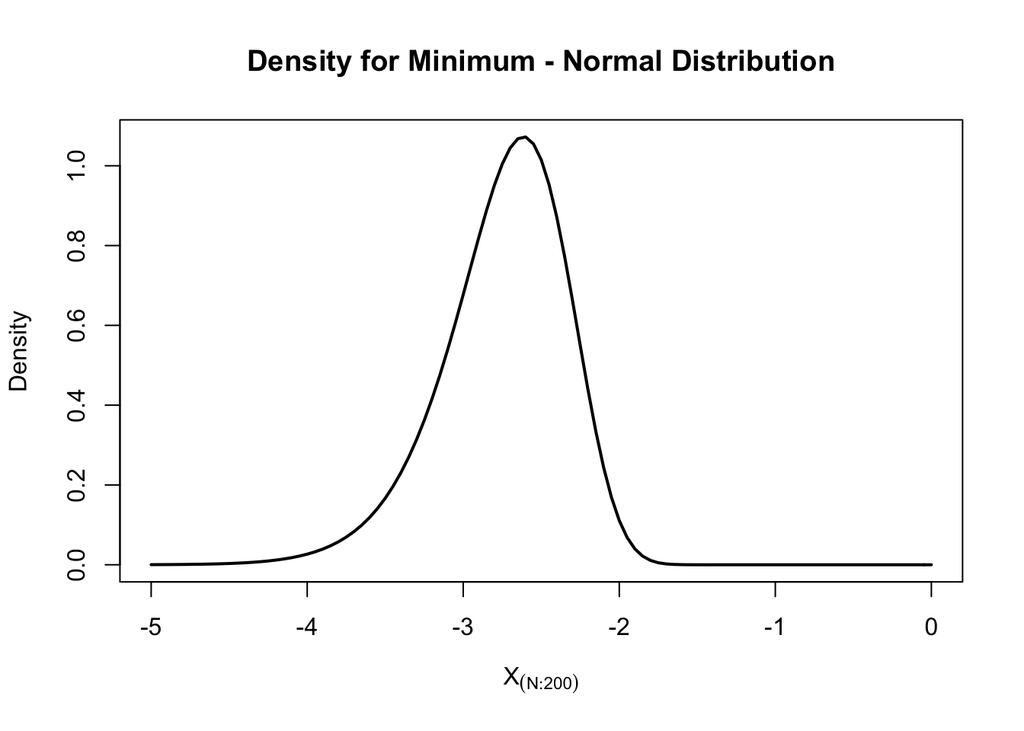

```r
curve(
  dorder(x, k=1, n=200, dist = "norm")
  , xlim = c(-5, 0)
  , xlab = parse(text = "X[(N:200)]")
  , ylab = "Density"
  , lwd = 2
  , main = "Density for Minimum - Normal Distribution"
)
```

From this graphic, we can find the density function for minimal is not symmetric, and it increases from -4 and then decrease after -2.7 and most of minimal fall between (-4, -2).

Next, let’s plot the probability and density functions for the sample min (N=200) of gamma distribution

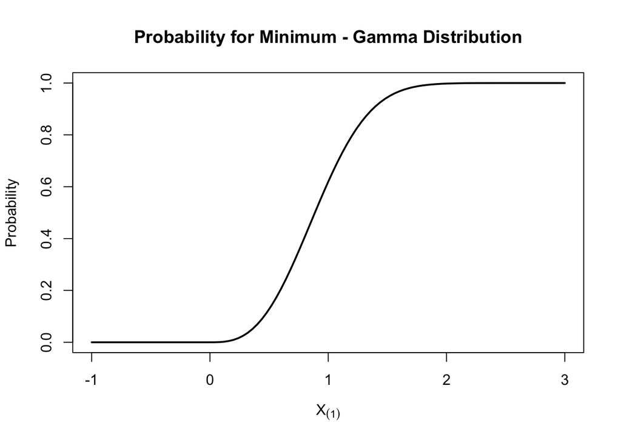

```r
curve(
  porder(x, k=1, n=200, dist = "gamma",shape=3,scale=3)
  , xlim = c(-1,3)
  , xlab = parse(text = "X[(1)]")
  , ylab = "Probability"
  , lwd = 2
  , main = "Probability for Minimum - Gamma Distribution"
)
```

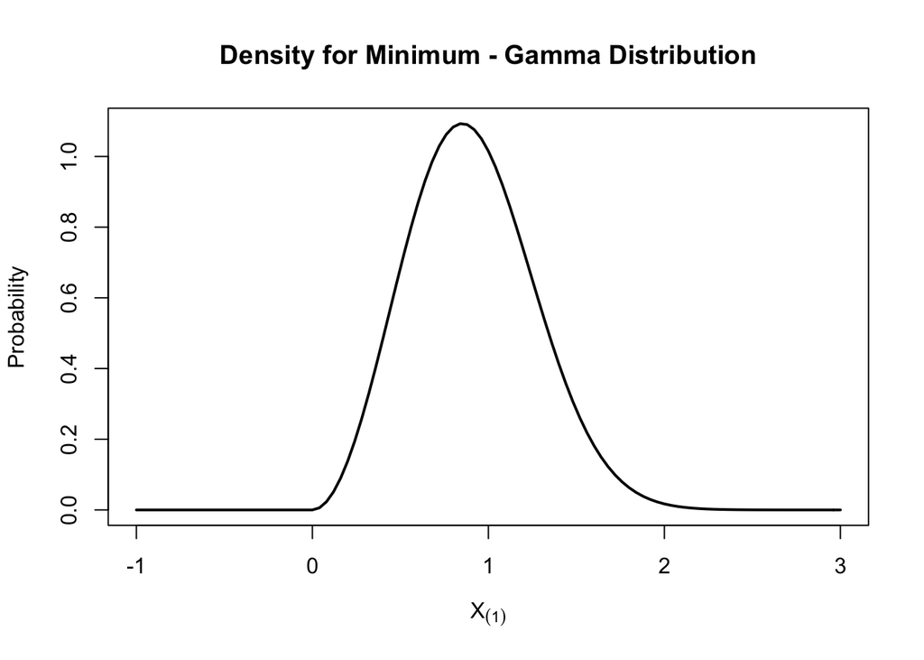

```r
curve(
  dorder(x, k=1, n=200, dist = "gamma",shape=3,scale=3)
  , xlim = c(-1,3)
  , xlab = parse(text = "X[(1)]")
  , ylab = "Probability"
  , lwd = 2
  , main = "Density for Minimum - Gamma Distribution"
)
```

From this graphic, we can see the gamma density function increases from 0 and then decrease from 1 and most of minimal fall between (0, 2).